# Week 4-2. Type I & II error and Power

< Back to Syllabus

### 1. Type I and Type II Error

#### 1.1 Hypothesis test review

- $H_0$: $\theta$=$\theta_0$
- $H_a$: $\theta \ne \theta_0$.
- Given a **test statistic**, the **null distribution** of the statistic, and a **significant level**, we are able to determine if we have enough evidence in the data to **reject the null hypothesis**.

#### 1.2 Errors

- When testing hypothesis, there are two possible errors that we can make:
  - **Type I error**: Rejecting the null when the null hypothesis is true.
  - **Type II error**: Not rejecting the null when the null hypothesis is false.

| Test vs. truth | $H_0$ is true | $H_0$ is false |
| --- | --- | --- |
| Reject $H_0$ | Type I error | Correct |
| Do not reject $H_0$ | Correct | Type II error |

- In classical statistics, we want to minimize the type I error, by setting a threshold to limit it to a pre-speciﬁed acceptable value, say 5%.
- The significance level of a test is the $\alpha$ that we find acceptable for the probability of a type I error.
- Good scientific and statistical practice is to set this value at the time you are designing the study, well before you look at any study data.
- The definition of type I error (or the level of significance) is

$$\alpha=\operatorname{Pr}\left(\text { Reject } H_{0} \mid H_{0} \text { is true }\right)$$

- We can control the probability of a type I error by setting the signiﬁcance level, $\alpha$.
- The definition of type II error is:

$$\beta=\operatorname{Pr}\left(\text { Do not reject } H_{0} \mid H_{0} \text { is false }\right)$$

- If we are just given a set of data, we can control the type I errors by setting the $\alpha$ as we are planning the analysis, before we look at the data.
- However in this case, we do not have control over the probability of a type II error and we just accept its value.
  - However, if we are designing a study from scratch, we can set both the type I error and type II error and determine the sample size needed to achieve these values.

> Study design 단계에서부터 필요한 sample size를 구하고 들어오면, type I and type II error 모두 control 가능함

#### 1.3 Power

- Usually, we are not interested directly in the type II error, but in its complement,

$$1-\beta=\operatorname{Pr}\left(\text { Reject } H_{0} \mid H_{0} \text { is false }\right)=\text { power }$$

- This is called the **power of the test**: the probability of correctly rejecting the null hypothesis when it is false.

| Test vs. Truth | $H_0$ is true | $H_0$ is false |
| --- | --- | --- |
| Reject $H_0$ | $\alpha$ (Type I error) | $1-\beta$ (Power) |
| Do not reject $H_0$ | $1-\alpha$ | $\beta$ (Type II error) |

#### 1.4 Illustration of type I and type II error

- Can use **density plots** to illustrate the relationship of $\alpha$, power $(1-\beta)$ and the null and alternative hypotheses.

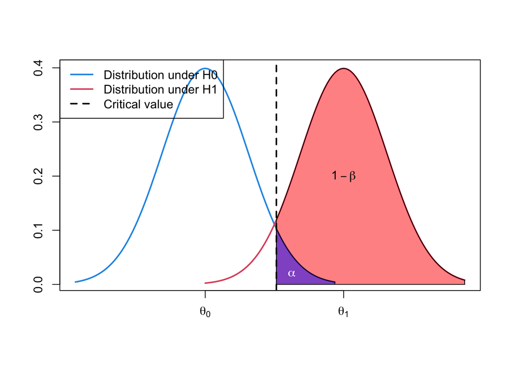

```r
curve(dnorm, from = -3, to = 3,
      xlim = c(-3, 6),
      lwd = 2, col = 4,
      axes = F, xlab = NA, ylab = NA)
curve(dnorm(x, mean = 3.2),
      add = TRUE, col = 2, lwd = 2, from = 0, to = 6)
coord.x <- c(qnorm(0.95), seq(qnorm(0.95), 6, by = 0.01), 6)
coord.y <- c(0, dnorm(coord.x[-c(1, length(coord.x))], mean = 3.2), 0)
polygon(coord.x, coord.y, col = rgb(1, 0, 0, 0.5))
coord.x <- c(qnorm(0.95), seq(qnorm(0.95), 3, by = 0.01), 3)
coord.y <- c(0, dnorm(coord.x[-c(1, length(coord.x))]), 0)
polygon(coord.x, coord.y, col = rgb(0, 0, 1, 0.5))
abline(v = qnorm(0.95), lty = 2, lwd = 2)
text(3.2, 0.2, labels = expression(1 - beta))
text(2, 0.02, labels = expression(alpha), col = "white")
axis(1, at = c(0, 3.2), labels = c(expression(theta[0]), expression(theta[1])))
axis(2)
box()
legend("topleft",
       c("Distribution under H0",
         "Distribution under H1",
         "Critical value"),
       bg = "transparent",
       lty = c(1, 1, 2),
       col = c(4, 2, 1), lwd = 2)
```

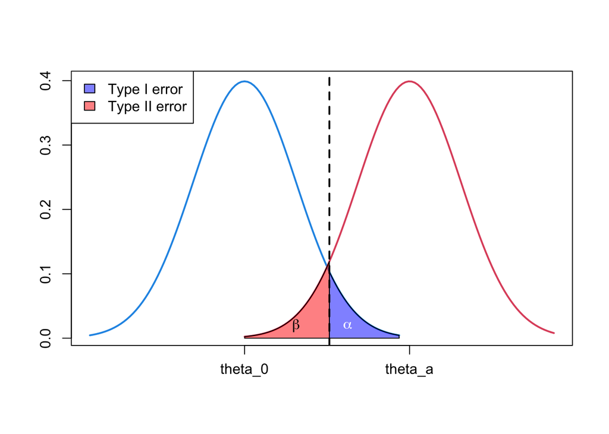

```r
curve(dnorm, from = -3, to = 3,
      xlim = c(-3, 6),
      lwd = 2, col = 4, axes = FALSE,
      xlab = NA, ylab = NA)
curve(dnorm(x, mean = 3.2),
      add = TRUE, col = 2, lwd = 2,
      from = 0, to = 6)
coord.x <- c(qnorm(0.95), seq(qnorm(0.95), 0, by = -0.01), 0)
coord.y <- c(0, dnorm(coord.x[-c(1, length(coord.x))], mean = 3.2), 0)
polygon(coord.x, coord.y, col = rgb(1, 0, 0, 0.5))
coord.x <- c(qnorm(0.95), seq(qnorm(0.95), 3, by = 0.01), 3)
coord.y <- c(0, dnorm(coord.x[-c(1, length(coord.x))]), 0)
polygon(coord.x, coord.y, col = rgb(0, 0, 1, 0.5))
abline(v = qnorm(0.95), lty = 2, lwd = 2)
text(1, 0.02, labels = expression(beta))
text(2, 0.02, labels = expression(alpha), col = "white")
axis(1, at = c(0, 3.2),
     labels = c(expression(theta_0), expression(theta_a)))
axis(2)
box()
legend("topleft",
       c("Type I error", "Type II error"),
       fill = c(rgb(0, 0, 1, 0.5),
                rgb(1, 0, 0, 0.5)))
```

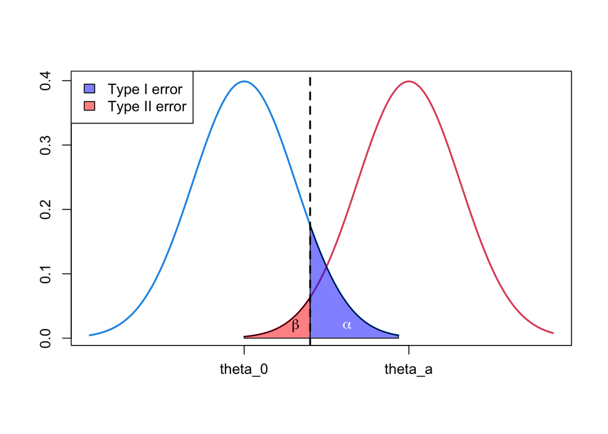

```r
curve(dnorm, from=-3, to=3,
      xlim=c(-3, 6), lwd=2, col=4,
      axes=FALSE, xlab=NA, ylab=NA)
curve(dnorm(x, mean=3.2),
      add=TRUE, col=2, lwd=2,
      from=0, to=6)
coord.x <- c(qnorm(0.9), seq(qnorm(0.9), 0, by=-0.01), 0)
coord.y <- c(0, dnorm(coord.x[-c(1, length(coord.x))], mean=3.2), 0)
polygon(coord.x, coord.y, col=rgb(1, 0, 0, 0.5))
coord.x <- c(qnorm(0.9), seq(qnorm(0.9), 3, by=0.01), 3)
coord.y <- c(0, dnorm(coord.x[-c(1, length(coord.x))]), 0)
polygon(coord.x, coord.y, col=rgb(0, 0, 1, 0.5))
abline(v = qnorm(0.9), lty=2, lwd=2)
text(1, 0.02, labels = expression(beta))
text(2, 0.02, labels = expression(alpha), col = "white")
axis(1, at = c(0, 3.2), labels = c(expression(theta_0), expression(theta_a)))
axis(2)
box()
legend("topleft",
       c("Type I error", "Type II error"),
       fill = c(rgb(0, 0, 1, 0.5),
                rgb(1, 0, 0, 0.5)))
```

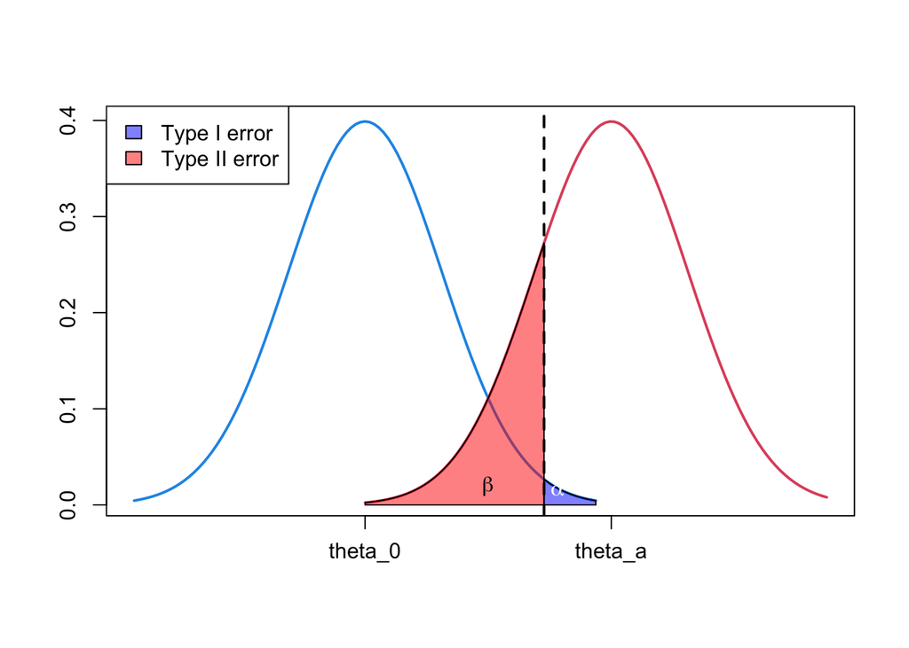

```r
curve(dnorm,
      from=-3, to=3,
      xlim=c(-3, 6), lwd=2, col=4,
      axes=FALSE, xlab=NA, ylab=NA)
curve(dnorm(x, mean=3.2),
      add=TRUE, col=2, lwd=2,
      from=0, to=6)
coord.x <- c(qnorm(0.99), seq(qnorm(0.99), 0, by=-0.01), 0)
coord.y <- c(0, dnorm(coord.x[-c(1, length(coord.x))], mean=3.2), 0)
polygon(coord.x, coord.y, col=rgb(1, 0, 0, 0.5))
coord.x <- c(qnorm(0.99), seq(qnorm(0.99), 3, by=0.01), 3)
coord.y <- c(0, dnorm(coord.x[-c(1, length(coord.x))]), 0)
polygon(coord.x, coord.y, col=rgb(0, 0, 1, 0.5))
abline(v = qnorm(0.99), lty=2, lwd=2)
text(1.6, 0.02, labels = expression(beta))
text(2.5, 0.015, labels = expression(alpha), col = "white")
axis(1, at = c(0, 3.2), labels = c(expression(theta_0), expression(theta_a)))
axis(2)
box()
legend("topleft",
       c("Type I error", "Type II error"),
       fill = c(rgb(0, 0, 1, 0.5),
                rgb(1, 0, 0, 0.5)))
```

### 2. Example: Binomial distribution

- simple random sample from a population with two outcomes (success and failure), with unknown probability of success $\pi$

```r
y <- rbinom(100, 1, 0.5)
```

- to test
  - $H_0: \pi= \pi_0=0.5$
  - $H_a: \pi= \pi_a>0.5$ (one-sided)
- Under $H_0$, $P$ has a rescaled $B(100, \pi_0)$ distribution.
- Under $H_a$, $P$ has a rescaled $B(100, \pi_a)$ distribution.
- (One-sided test) Rejection region: $(c, +\infty)$
  - where $c$ is called the **critical value**
- Since the sampling distribution of $P$ is a rescaled binomial, we can express $c$ either on the proportion scale or on the **number of successes scale**.
- Suppose we fix $\alpha$, then the **critical value** can be computed from the binomial distribution:

$$\operatorname{Pr}\left(Y>y_{1-\alpha} \mid H_{0}\right)=\alpha$$

- When $Y~B(n, \pi_0)$, then $P=Y/n$
- The **rejection region** is 95th percentile of the binomial distribution.

```r
(q <- qbinom(0.95, 100, 0.5))
```

```
## [1] 58
```

- Therefore, the **rejection region on the number of successes scale is $Y>58$ or on the sample proportion scale ($P$ scale) is:

$$\begin{array}{c}Y>58 \\ Y / 100>58 / 100 \\ P>0.58\end{array}$$

- The plot of the null distribution and the critical value on the sample proportion scale

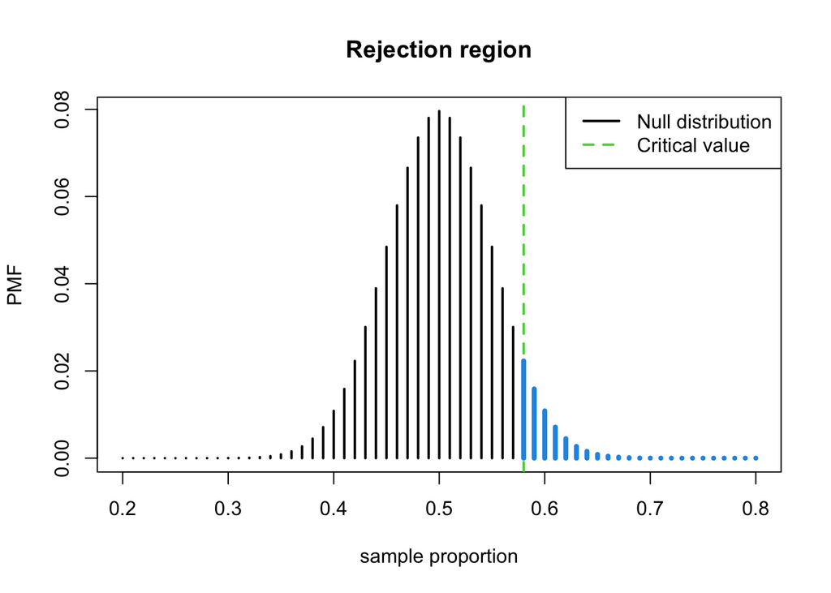

```r
pi_0 <- 0.5
n <- 100
plot((20:80)/100,dbinom(20:80, n, pi_0),
     type = "h",lwd=2,
     main="Rejection region",
     xlab = "sample proportion",
     ylab="PMF")
abline(v = 0.58, lty=2, lwd=2, col=3)
lines((58:80)/100, dbinom(58:80,n, pi_0),
      type = "h", lwd=4, col=4)
legend("topright",
       c("Null distribution", "Critical value"),
       lwd=2, lty=c(1, 2), col=c(1, 3))
```

- The probability of the blue region is approximately 0.05.

#### 2.1 Power

- Power = $1-\beta$
- In order to compute the power, we have to assume a specific value for the alternative distribution.
  - In this case, presume that the researchers believe that $\pi_a=0.6$.
  - This corresponds to a sample proportion of 0.60 or a $Y$ value of $Y=100 \times \pi_a=60$.

$$1-\beta=\operatorname{Pr}\left(\text { Reject } H_{0}|H_{a})=\operatorname{Pr}\left(Y>58 \mid \pi_{a}=0.6\right)\right.$$

- `R`: `pbinom()`

```r
(1 - pbinom(58, 100, 0.6)) %>% round(3)
```

```
## [1] 0.623
```

- Therefore, the chance we will get a statistically significant result (meaning a $p$-value < $\alpha=0.05$) **if the alternative hypothesis is true (i.e. under the alternative hypothesis) (e.g. $\pi_a=0.60$) is 0.623.
- The plot of power, the sum of the red bars for the $H_a$ PMF is the **power**

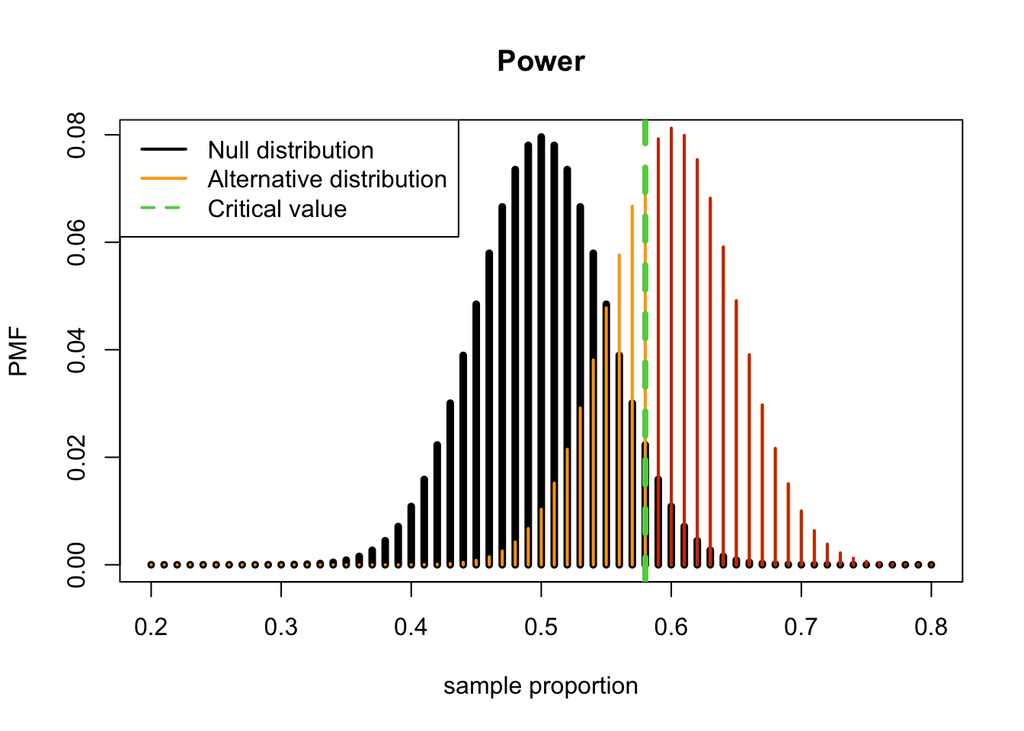

```r
pi.0 <- 0.5
pi.a <- 0.6
n <- 100
plot((20:80)/100,dbinom(20:80, n, pi.0),
     type = "h",lwd=5, main="Power",
     xlab = "sample proportion", ylab="PMF")
lines((20:80)/100,
      dbinom(20:80,n, pi.a),
      type = "h", lwd=2, col="orange")
lines((59:80)/100,
      dbinom(59:80,n, pi.a),
      type = "h", lwd=2, col="orangered3")
abline(v = 0.58, lty=2, lwd=4, col=3)
legend("topleft",
       c("Null distribution",
         "Alternative distribution",
         "Critical value"),
       lwd=2, lty=c(1, 1, 2),
       col=c(1, "orange", 3))
```

- Conclusion: We have 62.3% power to reject $H_0: \pi=0.5$ when the true population proportion is $\pi=0.60$ with a sample size of $n$ and a 5% (one-sided) level of significance.
- `R` function to calculate the **power**: `propTestPower()` in the `EnvStats` package.

```r
library(EnvStats)
```

- To get the power using an **exact binomial distribution**: set the argument to `approx = F` in `propTestPower()`.
  - `approx = T` will make the function use a **normal approximation** to the binomial to determine the power.

```r
samplePower <- propTestPower(100,0.6, 0.5,
                             alpha=0.05,
                             sample.type = "one.sample",
                             alternative = "greater",
                             approx=FALSE)
samplePower
```

```
## $power
## [1] 0.6225327
##
## $alpha
## [1] 0.04431304
##
## $q.critical.upper
## [1] 58
```

- Due to the discreteness of the binomial distribution, the $\alpha$ is not exactly equal to the specified value.
- Conclusion: Using one-sided level of significance of 0.05 with a sample size of $n$, there is 62.3% probability to detect a $\pi_a=0.60$. The critical value is 58, meaning that if we observe more than this many successes, 58, we would reject the null hypothesis, $H_0$.
> - We DO NOT use the values of the sample in any of our calculations.
> - This means we can compute the power of a test BEFORE performing the experiment.
> - The power is actually determined during study design.
> - It is not particularly useful to determine power after you have your data.
> - The power associated with a sample can be better conveyed by presenting the confidence interval for your estimate.
> - **If the confidence interval is wide, this means that the study did not have very high power.**

### 3. Power

#### 3.1 Power curve

- So far, we have been interested in testing hypotheses, $H_a: \pi>\pi_0$, where there are many values of $\pi$ under $H_a$.
  - Also, $H_a:\pi<\pi_0$.
- `R`: the power of a range of values of $\pi_a$

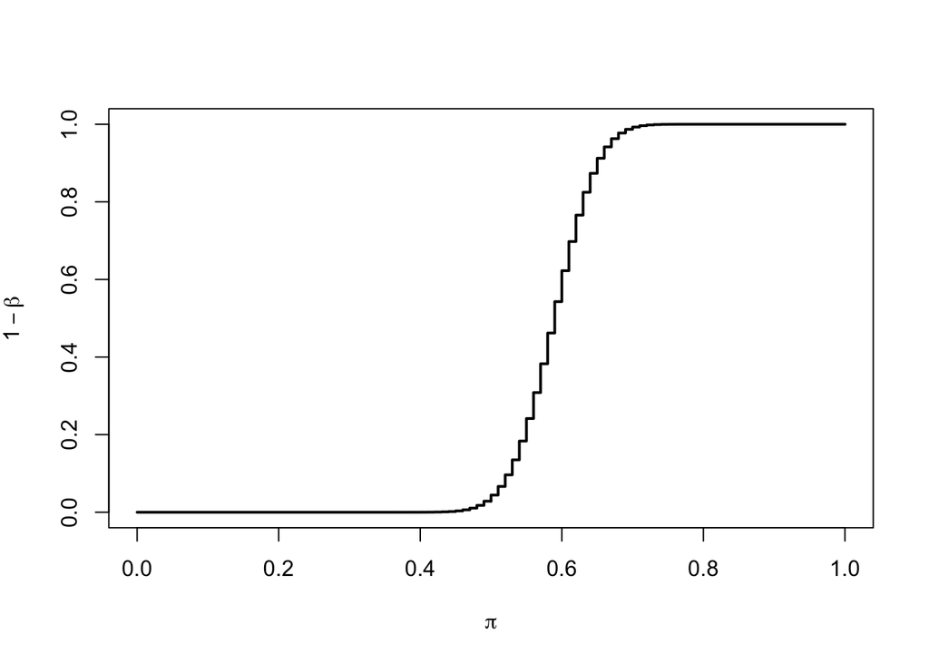

```r
pi.a <- seq(0, 1, by = 0.01)
power <- 1 - pbinom(qbinom(0.95,100,0.5), 100, pi.a)

# Power curve with the sample size of n=100 for a population proportion
plot(pi.a, power,
     type='s', lwd=2,
     ylab=expression(1-beta),
     xlab=expression(pi))
```

- Features of the power curve:
  - <1> the curve converges to $\alpha=0.05$ when $\pi$ gets closer to $\pi_0=0.5$
  - <2> the power increases with the distance between $\pi$ and $\pi_0$
  - <3> the curve converges to 1 as $\pi$ gets further from $\pi_0$

#### 3.2 Power and sample size

- Power depends on the sample size.
- By increasing the number of observations in the sample, we can increase the power of the test (i.e., $1-\beta$ or decreasing the Type II error).
- The **power of the test** is important in order to understand **what magnitude of effects we will be able to test**.
- In particular, this is important for studies that do not have a statistically significant result.
  - Because the studies that have a statistically significant reuslt already have enough power.
- ($p$-value > $\alpha$) the result is said not to be statistically significant.
- The question is
  - whether this is because $H_0$ is true, or
  - because we did not have enough power to detect a difference of interest.
- Often, researchers decide what power they need to test a given effect size and plan to collect a sample of a size $n$ that will give them enough power.
- `R`: the plot of the power of a test as a function of sample size

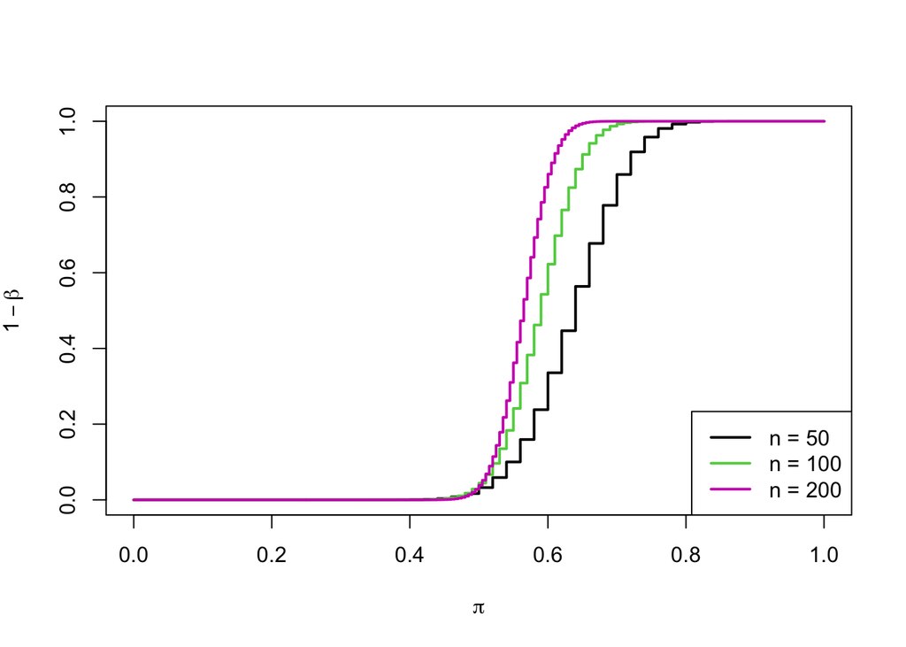

```r
pi.a50 <- seq(0, 1, by = 0.02)
pi.a100 <- seq(0, 1, by = 0.01)
pi.a200 <- seq(0, 1, by = 1/200)

power50 <- 1 - pbinom(qbinom(0.95,50,0.5), 50, pi.a50)
plot(pi.a50, power50, type='s', ylab=expression(1-beta), xlab=expression(pi), lwd=2)

power100 <- 1 - pbinom(qbinom(0.95,100,0.5), 100, pi.a100)
lines(pi.a100, power100, type='s', col=3, lwd=2)

power200 <- 1 - pbinom(qbinom(0.95,200,0.5), 200, pi.a200)
lines(pi.a200, power200, type='s', col=6, lwd=2)

legend("bottomright", paste0("n = ", c(50,100,200)), lwd=2, col=c(1,3,6))
```

#### 3.3 What do we know?

- In general we know $\pi_0$ and $\alpha$.
- $\pi_0$ is often based on historical data and the research team determines the $\alpha$ they want to use.
- In order to compute this **power**, we need to specify two of the following three:
  - $n$, $\beta$, $\pi_a$
  - Usually, we want to know what is the power for a given $\pi_a$ and $n$ or
  - we want to know what sample size $n$ we need to obtain a certain power, $1-\beta$, and $\pi_a$.

#### 3.4 Effect size

- Power depends only on:
  - $n$, the sample size
  - the difference between the null and alternative proportions also known as **effect size**

- What is the samllest sample size $n$ that we need to achieve a given power?
  - Very common question in biostatistics
  - Because when we are testing experimental treatments on patients, we do not want to harm patients unnecessarily.

> It is a moral obligation to:
> - <1> collect a sample size large enough to be able to prove an effect if there is one.
> - <2> collect a sample size small enough to avoid potentially harming many people.
- This process is generally refeered to as **power calculation**
- It involves making decisions on:
  - $\alpha$: a significance level
  - $\pi_a$: we want to be able to detect
  - $1-\beta$: the power of the test
- Example: suppose that we want a 80% chance to reject $H_0: 0.5$ at $\alpha=0.01$ if the true proportion is $\pi_a=0.65$ with one-sided test. What is the smallest sample size $n$ that we need?
- The given information is:
  - $1-\beta=0.80$
  - $\pi_a=0.5$
  - $\alpha=0.01$
  - $\pi_a=0.65$
- `R`: `propTestN`

```r
sampleSize <- propTestN(0.65, 0.5, alpha = 0.01, power = 0.80,
                        sample.type = "one.sample",
                        alternative = "greater",
                        approx=FALSE)
sampleSize
```

```
## $n
## [1] 114
##
## $power
## [1] 0.817283
##
## $alpha
## [1] 0.009405374
##
## $q.critical.upper
## [1] 69
```

- Set `approx=F`: the function compute the sample size using the exact binomial.
  - `approx=T`: the function uses a normal approximation to the binomial.
- Since the function uses an exact binomial, it is not possible sometimes to get the exact power and $\alpha$ that are stated.
  - This is because of the discreteness of binomial distribution.
- The program determines the value as close as possible doing a search.
- Conclusion: the required sample size would be 114 with one-sided $alpha=0.01$ and power of 81.7%.

#### 3.6 What is the minimum detectable difference? (given $n$, power)

- `propTestMdd` in the `EnvStats` package is the function to determine the **minimum detectable difference** if the sample size $n$ is known and for a desired level of power.
- e.g. Suppose we have a sample size 100 and want 90% power with $alpha=0.05$, one-sided significance.

```r
propDetectDiff <- propTestMdd(100, 0.50, alpha = 0.05, power = .9,
                              sample.type = "one.sample",
                              alternative = "greater",
                              approx=FALSE)
propDetectDiff
```

```
## $delta
## [1] 0.1465346
##
## $power
## [1] 0.9
##
## $alpha
## [1] 0.04431304
##
## $q.critical.upper
## [1] 58
```

#### 3.7 Summing up

- As the difference between means increases, power increases.
- As the sample size increases, power increases.
- As the significance level increases, power increases.
- To compute the **sample size**, for a single population proportion using an exact binomial, use `propTestN()`.
  - You need **power**, **significance level** $\alpha$, and the **difference to detect**.
- To compute the **power** for a sample of a single population proportion using an exact binomial, use `propTestPower()`.
  - You need the **sample size** $n$, **significance level** $\alpha$, and the **difference to detect**.
- To compute the **minimal detectable difference** for a single population proportion using an exact binomal, use `propTestMdd()`.
  - You need the **sample size** $n$, **significance level** $\alpha$, and the **power**.

< Back to Syllabus